# ECHomework-MonteCarloSimulations

### 2.4 histogram plot of the values of 𝑑

[output not shown]

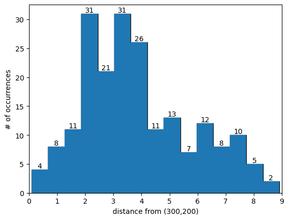

```python
#getting the plt.hist module from lecture 18
plt.hist(dist_from_center, color='blue', edgecolor='black', bins=15)
plt.xlim(0,9)
plt.xlabel("distance from (300,200)")
plt.ylabel("# of occurrences")

# I googled, " how to add labels to histogram in pyplot" to get labels for the bars
values, bins, bars = plt.hist(dist_from_center, bins=15)
plt.bar_label(bars)
```

```python
print(f" the sum of all of the values of the histogram is: {np.sum(values)} this is equal to the number of points I generated, {N}")
```

```
 the sum of all of the values of the histogram is: 200.0 this is equal to the number of points I generated, 200
```

### 2.5 the mean cluster center-to-star distance for the stars in my simulated cluster

The mean distance to a star from the cluster center can be simply calculated by using the numpy.mean(array) method for the (dist_from_center numpy array

```python
mean_dist = np.mean(dist_from_center)
```

```python
print(f" the mean cluster center-to-star distance for the stars in my simulated clusteris, {mean_dist} parsecs")
```

```
 the mean cluster center-to-star distance for the stars in my simulated clusteris, 3.8772203780601004 parsecs
```

## 3 Coding Assignment: Measuring the Half Life of Verarubinium

### 3.1 Make a function that accepts two variables, N and trueHalfLife, and “simulates” the random decay of N atoms

```python
def rand_decay( N, trueHalfLife, display):
    '''

    ---------inputs---------
    N: integer
    N is the number of atoms


    trueHalflife: float
    tureHalflife is the half-life of the atoms

    display:boolean
    display tells the rand_decay function if it should or should not print the output

    '''
    scale = trueHalfLife / np.log(2)
    #print(f"scale = {scale}")
    timeDecay = np.random.exponential(scale, N) # Generates a numpy array with N random numbers from an exponential distribution with a scale of the variable scale
    sortedarray = np.sort(timeDecay) #ordering the random list from least to greatest

    if N % 2 == 0: #if the value of N is even
        middle =  int((len(sortedarray))/2)-1 #finding the lindex of the lower value of the middle
        middle2 = int((len(sortedarray))/2) #finding the lindex of the higher value of the middle

        average = (sortedarray[middle] + sortedarray[middle2])/2 # calculating the average value of the middle of the sorted array of decay times
        #print(f"{middle} and  {middle2}")
        #print(f" {sortedarray[middle]} amd  {sortedarray[middle2]}")
        #print(average)

        if display: #testing if you want to print the output
            print(f"the decay times of all of the atoms are: \n{sortedarray} \n \n the time at which half the atoms have decayed is, {average} seconds") #printing the results
            return(average)
        else:
            return(average)
    else: #if the value of N is odd



        middle = int((len(sortedarray) -1)/2) #finding the index vale of the middle
        #print(middle)
        #print(sortedarray[middle])

        if display: #testing if you want to print the output
            print(f"the decay times of all of the atoms are: \n{sortedarray} \n \n the time at which half the atoms have decayed is, {sortedarray[middle]} seconds") #printing the results
            return middle
        else:
            return middle
```

```python
N = 20 #atoms
trueHalfLife = 100 #seconds
display = True

average = rand_decay( N, trueHalfLife, display)

print(average)
```

```
the decay times of all of the atoms are:
[ 19.93596981  31.73980446  32.15566123  51.03889648  60.70263172
  67.71759097  79.55099133 108.4423906  119.72475291 121.57131424
 155.64418854 163.88021217 268.68099771 354.63588757 355.54397008
 366.62101953 452.298887   509.09407682 708.83162492 856.17321409]

 the time at which half the atoms have decayed is, 138.6077513885394 seconds
138.6077513885394
```

### 3.2 Using the predicted value of 12.0 𝜇s as the true half-life, run 200,000 simulations of your 4-atom experiment, storing the half-life “measured” by each

```python
N = 4 #atoms
trueHalfLife = 12 #micro seconds
display = False # making sure the function only returns the average half-life
simulations = 200000 #the number of times I would like to run the for loop

measured_half_lives = [] #creating an empty list to store the measured half-lives


for i in range(simulations): #running the for loop the number of times simulations require
    average = rand_decay( N, trueHalfLife, display)
    measured_half_lives.append(average)

print(len(measured_half_lives)) #making sure my final list of measured_ha;f_lives is the correct length
```

```
200000
```

### 3.3 Make a histogram of the results

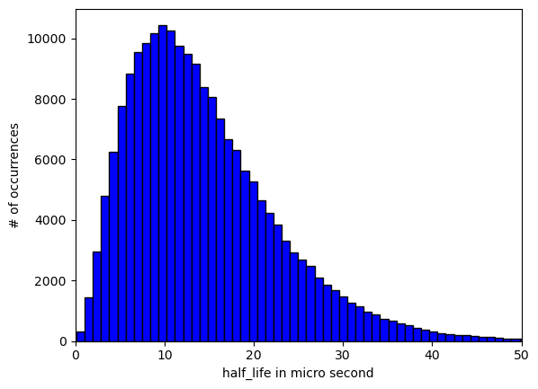

```python
plt.hist(measured_half_lives, color='blue', edgecolor='black', bins=100)
plt.xlim(0,50)
plt.xlabel("half_life in micro second")
plt.ylabel("# of occurrences")
```

### 3.5 In what fraction of your simulations do you measure the half-life to be 25 𝜇s or greater?

```python
print(len(measured_half_lives))
half_lives = np.array(measured_half_lives) #creating an array of measured_half_lives
greater_than_25 = half_lives > 25 #masking half_lives array
print(len(half_lives[greater_than_25])) #checking the length of the masked list
ratio = len(half_lives[greater_than_25])/len(measured_half_lives)
print(f"the ratio of measured half lives grater than 25 is {ratio}")
```

```
200000
22044
the ratio of measured half lives grater than 25 is 0.11022
```

the ratio as a fraction is: $$ \frac{len(half_lives[greater_than_25])}{len(measured_half_lives)} =\frac{22044}{200000} = 0.11022$$

Since the chance of getting a half life of greater than 25 microseconds appears to be around 11%, I believe if you get one result of a half life of 25 microseconds that would still be a publishable result because it has a probability of 0.11022 = 11.022% but, I have not taken a statstics class and do not fully understand how to calculate 3𝜎 for this experiment